# 运用于仓位管理的Kelly公式

Ernest Chan在[《Quantitative Trading》](https://book.douban.com/subject/3361807/)书中认为策略组合的最优化配置与证券组合的最优化配置在数学上是基本等价的，如果我们的策略通过回测得到近似的预期收益率，则可以借鉴最优化配置的方法来调整策略的杠杆。Edward Thorp在其系列论文 [THE KELLY CRITERION IN BLACKJACK, SPORTS BETTING, AND THE STOCK MARKET by Edward O. Thorp Paper presented at: The 10th International Conference on Gambling and Risk Taking Montreal, June 1997](https://wayback.archive-it.org/all/20090320125959/http://www.edwardothorp.com/sitebuildercontent/sitebuilderfiles/KellyCriterion2007.pdf)对这个问题进行了探讨，对理论感兴趣的可以直接看此论文。

#### 一、Kelly公式的基本推导

对Kelly公式的简单推导如下：

假设我们玩一个非胜即负的游戏，赢的概率为p，收益率为$r_w$，输的概率为1-p，收益率为$ - r_l$，即我们的收益为两点分布（$r_w$，$ - r_l$；p，1-p）

初期资金为$W_0$，期末资金为$W_T$，每次下注金额为$fW_t$，则有

$W_t = W_0 \prod_{t=0}^{T}(1 + fR_t)$

长期复合增长率为

$g（f）=\lim_{T->\infty}(1/T)ln(W_T/W_0) = pln(1+fr_w) + (1-p)ln(1-fr_l)$

令g(f)最大，则需要$\Delta g/\Delta f = 0$

于是有

$f^* = \frac{pr_w - (1-p)r_l}{r_w r_l} = E(R)/r_w r_l$

该公式同时表明了只有在收益期望为正的情况下，我们才下注。

```python
import random
import numpy as np
import pandas as pd
import matplotlib.pyplot as plt
import matplotlib

matplotlib.rcParams['figure.figsize'] = (12, 8)
```

```python
def simulator(rw = 1.0, rl = 1.0, p = 0.51):
    w = [1] * 5
    w_list = [[],[],[],[],[]]
    f = round((p*rw - (1 - p)*rw)/(rw*rl),3)
    F = [f, f*0.5,f*1.5,f*2,f*3]
    for i in range(10000):
        r = random.uniform(0,1)
        for j in range(len(F)):
            if r <= p:
                w[j] = w[j] * (1 + F[j] * rw)
            else:
                w[j] = w[j] * (1 - F[j] * rl)
            w_list[j].append(w[j])
    plt.plot(w_list[0], 'r', label = str(F[0]))
    plt.plot(w_list[1], 'b', label = str(F[1]))
    plt.plot(w_list[2], 'b', label = str(F[2]))
    plt.plot(w_list[3], 'b', label = str(F[3]))
    plt.plot(w_list[4], 'b', label = str(F[4]))
    plt.legend()
    plt.show()
```

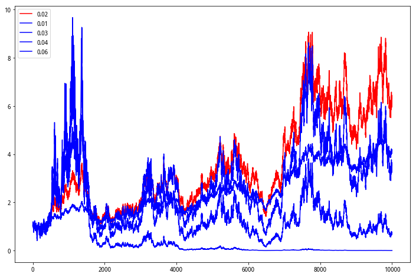

```python
simulator()
```

利用蒙地卡罗模拟10000次概率p，Kelly公式仓位比例和其他仓位比例的净值对比，多数情况下建议优于其他仓位。

#### 二、适用于正态分布的Kelly公式

上方的公式是收益率为两点分布的极端情况，然而大多数情况下，收益率的分布是难以预测的，但任何模型都是从最简单的情况开始推导，金融市场也不例外，对于真实市场里的一些限制处理，则是咱们需要努力的地方。

如果我们认为股票的价格是完全“随机漫步”，则我们可以假设收益率服从近似正态分布$N(m-\sigma^2/2,\sigma)$,其中m为平均单期收益率，$\sigma$为单期收益率的标准差。

假设r为无风险利率，则我们可以配置仓位f到股票上，1-f到无风险利率为r的资产上，从Thorp在论文中给出适用于正态分布的复合增长率为：

$g(f) = fm + (1-f)r - 1/2 f^2\sigma^2$

令g(f)最大，则需要$\Delta g/\Delta f = 0$

于是有

$f^* = \frac{m - r}{\sigma^2}$

#### 三、投资组合的Kelly公式

上面考虑的是单一策略的情况，此公式可以扩展为策略组合的情况

假设列向量 $F = (f_1, ... f_n)^T$ 为配置到n个策略上的净值比例，则最优配置公式为

$F^* = C^{-1} M$

其中C为协方差矩阵，$C_{ij}$表示第i个策略和第j个策略超额收益率的协方差，列向量$M = (m_1 ... m_n)^T$，其中$m_i$表示策略i单期无杠杆平均超额收益率

如果每个策略之间的相关性为0，则协方差矩阵C变成对角矩阵，对角线变成每个策略的收益率的方差，则有

$f_i^* = \frac{m_i}{\sigma _i^2} $，亦即上面公式。

```python
# 以期货沪银、沪铜、螺纹钢和橡胶举例
# 由于期货每手合约的单位都是不同的，为了简化，先以行情报价作为一个单位
```

```python
df = get_price(['AG88', 'CU88', 'RB88', 'RU88'], start_date = '2016-01-01', end_date = '2018-07-01', fields = 'close', adjust_type='pre')
```

```python
df.head()
```

|  | AG88 | CU88 | RB88 | RU88 |
| --- | --- | --- | --- | --- |
| 2016-01-04 | 3305.0 | 35970.0 | 1777.0 | 10160.0 |
| 2016-01-05 | 3313.0 | 36510.0 | 1789.0 | 10190.0 |
| 2016-01-06 | 3314.0 | 36240.0 | 1775.0 | 10070.0 |
| 2016-01-07 | 3357.0 | 36090.0 | 1773.0 | 10080.0 |
| 2016-01-08 | 3356.0 | 35680.0 | 1759.0 | 10090.0 |

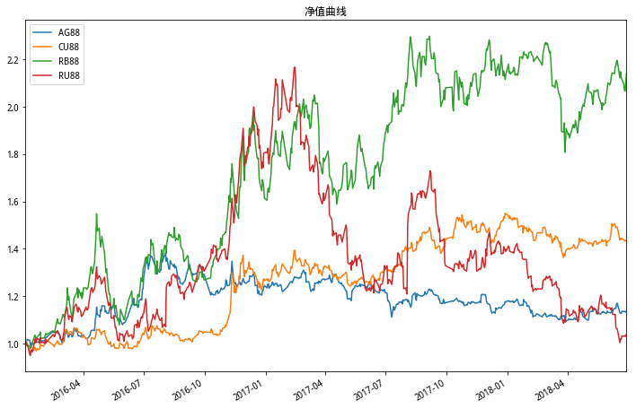

```python
(df / df.iloc[0]).plot()
plt.title(u'净值曲线')
plt.show()
```

```python
def calculate_kelly(df, ret_f = 0.04 / 250):
    # 计算收益率
    ret = df.diff(1)/df.shift(1)
    ret.ix[0,:] = 0
    # 年化超额收益率的协方差矩阵为
    C = np.mat(((ret - ret_f).cov() * 250).values)
    # 年化超额收益率的列向量为
    M = np.mat(((ret - ret_f).mean() * 250).values).T
    # Kelly公式的最优化建议为
    F = C.I * M
    return F.T.tolist()[0]
```

```python
F = calculate_kelly(df)
```

```python
F
```

```
[-0.5761100577537259,
 2.648960992339988,
 2.822894723017085,
 -1.3455186406661763]
```

Kelly公式的建议表明了单位报价的杠杆比例，建议为负即做空。

假设账户资金为M，

考虑到AG,CU,RB,RU的手数单位和报价的比例为15,5,10,10，即每个合约的价值为V = ($15p_{ag}$,$5p_{cu}$,$10p_{rb}$,$10p_{ru}$)

无杠杆下当合约价值为M时，需要做M/V手，因此交易手数为 F * M/V

```python
# 每手合约价值为报价乘以每手的单位
P = np.array(df.iloc[-1].tolist())
V = P * np.array([15,5,10,10])

M = 1000000
F_h = (M * np.array(F) / V).tolist()
F_h = [int(f) for f in F_h]
F_h
```

```
[-10, 10, 74, -12]
```

以上为资金1000000时，Kelly公式建议的最优交易手数

#### 四、限制条件

考虑到成本问题和流动性的风险，Thorp建议应该以一半的杠杆建议即$\frac{1}{2}F$来进行配置。

在A股市场里，一般情况下是既不能用杠杆也不允许做空。

对于杠杆的情况，假设最大杠杆比例为$F_{max}$

仓位的净值比例$f_i^{**}$为$f_i^*$乘上杠杆因子$F_{max}/\sum_{i}^{n}|f_i^*|$，如果不允许使用杠杆，则$F_{max}=1$

对于不允许做空的情况，可以预想一种处理方法是对建议为负的仓位修正为0，将其资金分配给其他建议为正仓位的策略。

然而这个方法在实际上可能并不比等比例分配有效。

```python
# 以股票为例
df2 = get_price(['600004.XSHG', '600276.XSHG', '002304.XSHE'], start_date = '2017-05-01', end_date = '2018-05-01', fields = 'close', adjust_type='pre')
```

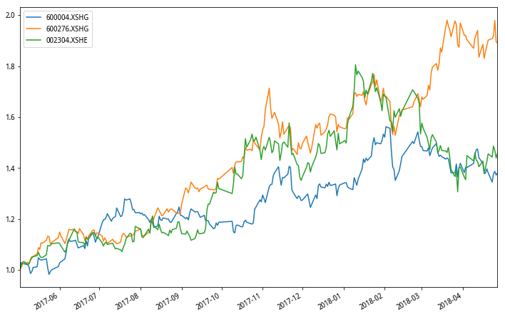

```python
(df2 / df2.iloc[0]).plot()
plt.show()
```

```python
F2 = calculate_kelly(df2)
```

```python
# Kelly公式给出的建议杠杆为
F2
```

```
[1.260155309200076, 6.301383592143694, 0.7591765835953153]
```

```python
# 仓位限制为1时，Kelly公式的仓位比例为
F2h = np.array(F2)
F2h = (F2h / np.fabs(F2h).sum()).tolist()
F2h
```

```
[0.15144795077791331, 0.7573127098924984, 0.09123933932958807]
```

#### 四、与均值-方差模型的对比

经典投资组合理论里面，马科维茨的均值-方差理论认为：

投资组合的方差 $\sigma^2 = h^{T}Vh$

其中列向量$h = (h_1, ... h_n)^T$为每个资产在总资产的权重，V为各资产收益率的协方差矩阵

由于$Sharpe = E(R)/\sigma$

而预期收益率E(R)可以由各资产的超额收益率的均值乘以权重来估算，即$E(R) = \sum h_i * mean(r_i - rf) * 250$

因此可以用最小化$\sigma$或最大化Sharpe的方法来估算h。

```python
# 这里我们应用蒙特卡洛模拟，生成较大规模的随机投资组合权重向量。对于每一种模拟的分配，我们记录预期投资组合收益和标准差
def montecarlo_sim(df):
    # 收益率
    ret = df.diff(1)/df.shift(1)
    ret.ix[0,:] = 0
    # 无风险利率
    ret_f = 0.04/250
    # 模拟收益率和标准差列表
    ret_list = []
    s_list = []

    for i in range(10000):
        h = np.random.random(len(df.columns))
        h = h / np.sum(h)
        ret_list.append(np.sum((ret - ret_f).mean() * h) * 250)
        s_list.append(np.sqrt(np.dot(np.dot(h.T, (ret - ret_f).cov() * 250), h)))

    ret_array = np.array(ret_list)
    s_array = np.array(s_list)
    # 根据上面的结果，画出收益和方差的散点图
    plt.figure()
    plt.scatter(x = s_array, y = ret_array, c = ret_array/s_array, marker='o')
    plt.grid()
    plt.xlabel('expected std')
    plt.ylabel('expected return')
    plt.colorbar(label='Sharpe Ratio')
    plt.show()
```

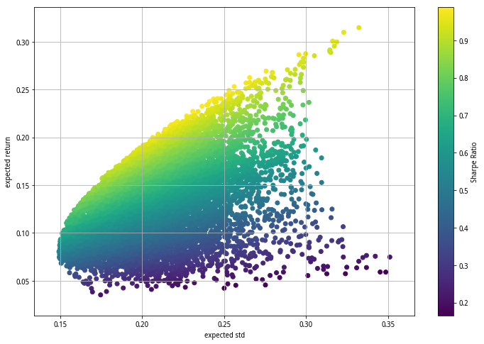

```python
montecarlo_sim(df)
```

利用模特卡洛模拟10000次仓位组合，得出组合收益率，波动率（标准差）以及夏普比率的点状态。

点状图构成的边界叫有效边界，也就是说我们的投资组合的收益率和标准差只能在有效边界之内，夏普比率实际上是y/x的斜率，我们的组合最优化问题就是在有效边界内求解。

```python
# 最大化sharpe的问题等于最小化 -1 * sharpe，可以利用scipy.optimize.minimize求解
import scipy.optimize

def mvm(df,mod = 'max_sharpe'):
    # 输入权重list(h),对df进行夏普比率计算
    def cal_stat(h):
        # 收益率
        ret = df.diff(1)/df.shift(1)
        ret.ix[0,:] = 0
        # 无风险利率
        ret_f = 0.04/250
        # 仓位比例的列向量
        h = np.array(h).T
        # 组合预期年化超额收益率
        ER = np.sum((ret - ret_f).mean() * h) * 250
        # 组合年化超额收益率的标准差
        s = np.sqrt(np.dot(np.dot(h.T, (ret - ret_f).cov() * 250), h))
        return s, ER/s, ER/250 - 1 * s**2
    # 最小化标准差
    def min_sigma(h):
        return cal_stat(h)[0]
    # 最大化sharpe等于最小化-1 * sharpe
    def max_sharpe(h):
        return -1 * cal_stat(h)[1]
    # 单期预期收益减去方差
    def max_return(h):
        return -1 * cal_stat(h)[2]

    # 总仓位限制条件，sum(h) - 1 = 0
    cons = ({'type':'eq', 'fun':lambda x: np.sum(x) - 1})
    # 仓位限制条件(0,1)
    bnds = tuple((0, 1) for x in range(len(df.columns)))
    # 开始的猜想，等比例配置
    initGuess = len(df.columns) * [1 / len(df.columns)]
    if mod == 'min_sigma':
        opts = scipy.optimize.minimize(min_sigma, initGuess, method='SLSQP', bounds=bnds, constraints=cons)
    elif mod == 'max_sharpe':
        opts = scipy.optimize.minimize(max_sharpe, initGuess, method='SLSQP', bounds=bnds, constraints=cons)
    elif mod == 'max_return':
        opts = scipy.optimize.minimize(max_return, initGuess, method='SLSQP', bounds=bnds, constraints=cons)
    return opts.x.tolist()
```

```python
mvm(df2,'max_sharpe')
```

```
[0.151440793887113, 0.7573257440231524, 0.09123346208973457]
```

可见对于拥有稳定正收益的资产组合，通过均值方差模型得出的结果和Kelly公式得出的结果基本一致

对于不允许做空的情况，均值方差模型的结果更为直接，以最初的期货数据为例

```python
mvm(df,'max_sharpe')
```

```
[0.0, 0.40898836222872553, 0.5910116377712745, 4.023203055473074e-17]
```

此外，均值方差模型亦可以通过最小化方差或最大化组合预期收益率减去n个方差（即$max(h^Tf - \lambda h^TVh$),$\lambda$为常数)来计算h，灵活性较高。

```python
mvm(df2,'min_sigma')
```

```
[0.48977689984568096, 0.31623646260037874, 0.19398663755394033]
```

```python
mvm(df2,'max_return')
```

```
[0.4854372948688476, 0.32319352288182845, 0.191369182249324]
```

#### 五、实际应用的限制

但无论是Kelly公式还是均值方差模型，都是用过去一段时间的收益率来得出那段时间的最优仓位配置。

我们需要假设：

1、收益率（或收益率的对数）呈近似正态分布

2、预期收益率可以通过过去的收益率（均值）来预测

如果假设成立，则我们可以把公式得出的最优仓位配置运用于实际应用里。我们可以假想通过投资组合的过去一段时间的来得出仓位配置，每过一段时间调仓一次。然而通过多次回测结果，无论是Kelly公式还是均值方差模型给出的仓位配置最后给出的业绩指标并不严格优于等比例分配。

我认为原因有几个：

1、假设1可能是错误的，收益率的分布大多不是严格的正态分布，而大多是一个尖峰厚尾的分布形态，而每一个资产或股票收益率的分布情况都可能大相径庭。

2、假设2可能是错误的，Kelly公式的基本形态对于先验概率可知的情况下是毫无疑问的，但在金融市场里，收益率预测是一个大难题。

3、回顾的窗口期不够长令分布失衡，调仓时间过长或过短等问题。

因此，要将理论转化为实际应用，还有很多工作要做。